# Overview of HPViewer

## Description

HPViewer is a tool for **genotyping and quantification of HPV from metagenomic or human genomic shotgun sequencing data.** We designed it to improve performance by masking nonspecific sequences from reference genomes and directly identifying HPV short DNA reads. It contains two HPV databases with different masking strategies, repeat-mask and homology-mask and one homology distance matrix to choose between those two databases.

**If you use the HPViewer software, please cite our manuscript:**

Yuhan Hao, Liying Yang, Antonio Galvao Neto, Milan R. Amin, Dervla Kelly, Stuart M. Brown, Ryan C. Branski, Zhiheng Pei. **“HPViewer: Sensitive and specific genotyping of human papillomavirus in metagenomic DNA”** (Submitted)

## Installation

```bash
$ git clone https://github.com/yuhanH/HPViewer.git
```

### Pre-requisites

Python (2.7+)

Python packages (sys, getopt, subprocess)

Bowtie2: http://bowtie-bio.sourceforge.net/bowtie2/manual.shtml

SAMtools: http://www.htslib.org/

Bedtools: http://bedtools.readthedocs.io/en/latest/

## Parameters

### Required

1. input files (**-U** or **-1 -2** ): fastq files (or fastq.gz), unpaired (-U unpaired.fastq) or R1,R2 paired (-1 R1.fastq -2 R2.fastq)
2. output file name (**-o**)

### Optional

1. database mask type (**-m**): hybrid-mask(default), repeat-mask, homology-mask. repeat-mask is a more sensitive mode; and homology-mask is suggested when some types of HPV are present in large abundance which may lead to false positive of other types of HPV.
2. number of threaded used in bowtie2 alignment (**-p**)
3. minimal coverage threshold to determine HPV present (**-cov**), default is 150 bp (1.5 x average length of your reads).

## Results

2. alignment results after bowtie2: output.sam, output.bam

## Basic Usage (demo)

```bash
python HPViewer2.py -U test_unpaired.fastq -o TEST
```

```bash
more TEST/TEST_HPV_profile.txt
```

```
## HPV_type RPK(reads_per_kilobase) count_of_reads
## HPV5 114.3199    859
## HPV7 109.0264    860
## HPV21    120.3347    906
## HPV49    109.3479    820
## HPV66    123.1417    936
## HPV69    108.1513    812
## HPV73    117.2339    868
## HPV88    126.1261    924
## HPV101   115.1348    833
## HPV117   116.1049    899
```

## Workflow

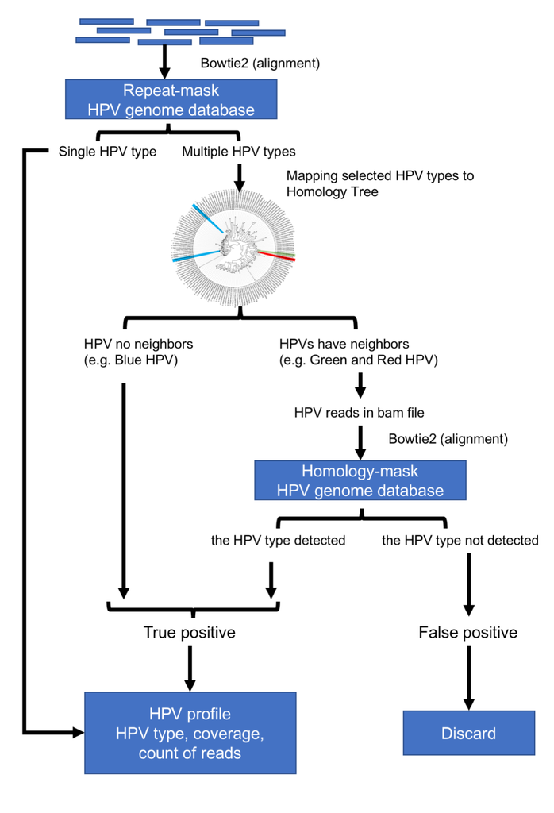